# Ejercicios Torres

# 9 Ejercicio 10.2

Utilizando generos_5 y metadata_riz:

Identifica las plantas hospederas que tienen al menos 5 muestras. Conserva únicamente las muestras correspondientes a esas plantas. Construye una gráfica de barras apiladas de abundancia relativa por género con ggplot2, utilizando facet_wrap() para comparar las plantas hospederas.

```r
# Contar las muestras por planta hospedera
hospederos_elegidos <- metadata_riz %>%
  count(host_name, name = "n_muestras", sort = TRUE) %>%
  filter(n_muestras >= 5)

hospederos_elegidos
```

```
##    host_name n_muestras
##       <char>      <int>
## 1:    Tomato         21
## 2:     Maize         17
## 3: Soya bean         11
## 4:    Peanut          8
```

```r
# Filtrar los géneros de las plantas seleccionadas
generos_seleccionados <- generos_5 %>%
  filter(host_name %in% hospederos_elegidos$host_name)

head(generos_seleccionados)
```

```
## # A tibble: 6 × 4
##   sample_id   host_name taxon_final    abundancia_relativa
##   <chr>       <chr>     <chr>                        <dbl>
## 1 SRR11092499 Tomato    Bradyrhizobium              0.0647
## 2 SRR11092499 Tomato    Géneros < 5%                0.871
## 3 SRR11092499 Tomato    Streptomyces                0.0644
## 4 SRR11092502 Tomato    Géneros < 5%                0.851
## 5 SRR11092502 Tomato    Sphingomonas                0.0647
## 6 SRR11092502 Tomato    Streptomyces                0.0840
```

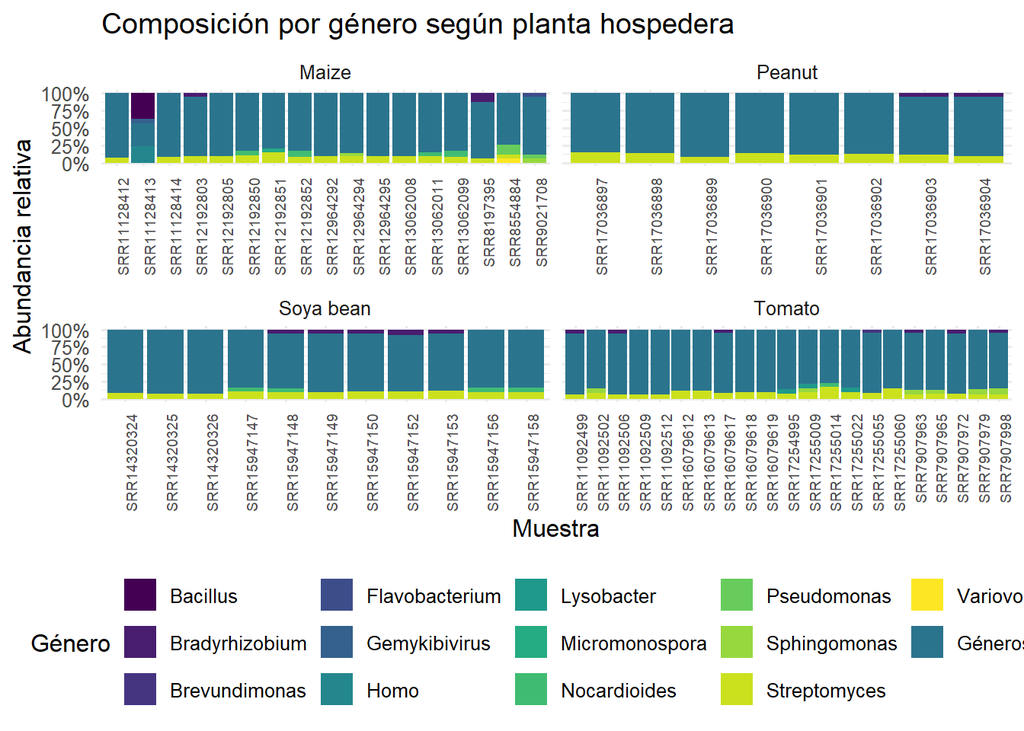

```r
# Colocar los géneros menores al 5% al final
orden_generos <- c(
  sort(setdiff(unique(generos_5$taxon_final), "Géneros < 5%")),
  "Géneros < 5%"
)

# Gráfica de abundancia relativa por género
p_generos <- ggplot(generos_seleccionados,
  aes(x = sample_id, y = abundancia_relativa, fill = taxon_final)) +
  geom_col() +
  scale_fill_viridis_d(option = "viridis",
                       breaks = orden_generos) +
  facet_wrap(~ host_name, scales = "free_x") +
  scale_y_continuous(labels = function(x) paste0(round(100 * x), "%")) +
  labs(title = "Composición por género según planta hospedera",
       x = "Muestra",
       y = "Abundancia relativa",
       fill = "Género") +
  theme_minimal(base_size = 12) +
  theme(axis.text.x = element_text(angle = 90, hjust = 1, size = 7),
        legend.position = "bottom")

p_generos
```

¿Qué diferencias observas en la composición taxonómica entre las plantas?

Las plantas tienen diferentes proporciones de géneros, pero en todas predominan los géneros agrupados en la categoría de menos del 5%

¿Todas las muestras de una misma planta presentan composiciones similares?

No del todo, porque aunque sean de la misma planta, algunos géneros son más abundantes en unas muestras que en otras.

## 9.1 Ejercicio 10.3

Utilizando filos_5 y metadata_riz:

- Identifica los países que tienen al menos 5 muestras.
- Conserva únicamente las muestras correspondientes a esos países.
- Construye una gráfica de barras apiladas de abundancia relativa por filo con ggplot2, utilizando facet_wrap() para comparar los países.
- Para discutir: ¿Qué diferencias observas en la composición taxonómica entre los países? ¿Las muestras de un mismo país presentan composiciones similares?

```r
# Contar las muestras por país
paises_elegidos <- metadata_riz %>%
  count(country, name = "n_muestras", sort = TRUE) %>%
  filter(n_muestras >= 5)

paises_elegidos
```

```
##         country n_muestras
##          <char>      <int>
## 1: South Africa         27
## 2:        China         21
## 3:       Mexico         10
## 4:  Netherlands          7
```

```r
# Agregar el país y conservar los países seleccionados
filos_seleccionados <- filos_5 %>%
  left_join(
    metadata_riz %>% select(sample_id, country),
    by = "sample_id"
  ) %>%
  filter(country %in% paises_elegidos$country)

head(filos_seleccionados)
```

```
## # A tibble: 6 × 5
##   sample_id   host_name taxon_final    abundancia_relativa country
##   <chr>       <chr>     <chr>                        <dbl> <chr>
## 1 SRR11092499 Tomato    Actinomycetota               0.294 Mexico
## 2 SRR11092499 Tomato    Filos < 5%                   0.153 Mexico
## 3 SRR11092499 Tomato    Pseudomonadota               0.553 Mexico
## 4 SRR11092502 Tomato    Actinomycetota               0.321 Mexico
## 5 SRR11092502 Tomato    Filos < 5%                   0.162 Mexico
## 6 SRR11092502 Tomato    Pseudomonadota               0.517 Mexico
```

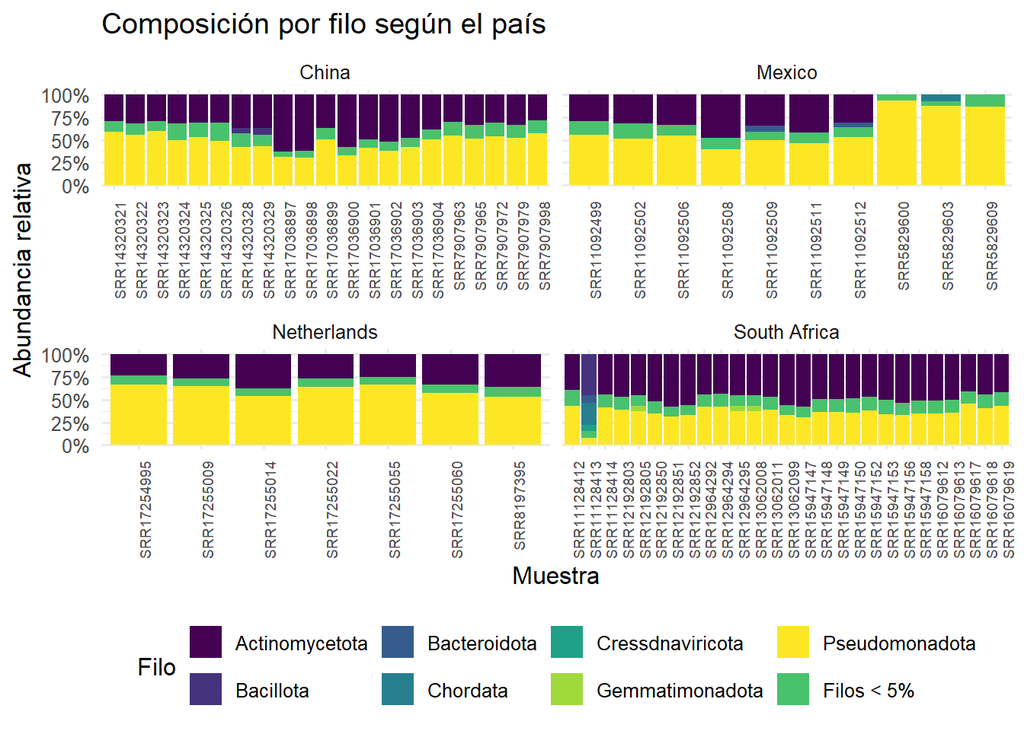

```r
# Colocar los filos menores al 5% al final
orden_filos <- c(
  sort(setdiff(unique(filos_5$taxon_final), "Filos < 5%")),
  "Filos < 5%"
)

# Gráfica de abundancia relativa por filo
p_filos <- ggplot(filos_seleccionados,
  aes(x = sample_id, y = abundancia_relativa, fill = taxon_final)) +
  geom_col() +
  scale_fill_viridis_d(option = "viridis",
                       breaks = orden_filos) +
  facet_wrap(~ country, scales = "free_x") +
  scale_y_continuous(labels = function(x) paste0(round(100 * x), "%")) +
  labs(title = "Composición por filo según el país",
       x = "Muestra",
       y = "Abundancia relativa",
       fill = "Filo") +
  theme_minimal(base_size = 12) +
  theme(axis.text.x = element_text(angle = 90, hjust = 1, size = 7),
        legend.position = "bottom")

p_filos
```

¿Qué diferencias observas en la composición taxonómica entre los países?

En México y Países Bajos predomina Pseudomonadota, mientras que en China y Sudáfrica hay una mayor proporción de Actinomycetota en varias muestras.

¿Las muestras de un mismo país presentan composiciones similares?

Sí, en general son parecidas, pero las proporciones de los filos varían entre muestras, aunque sean del mismo país.

# 10 Ejercicio 11

## 10.1 Pregunta 11.1

Si compartimos únicamente un archivo HTML con figuras, ¿estamos compartiendo necesariamente un análisis reproducible?

No porque cuando lo renderizo a HTML y lo subo a github solo aparece un código raro y nada reproducible.

## 10.2 Pregunta 11.2

Queremos que el HTML muestre una gráfica pero no las instrucciones de R que la producen. ¿Qué opción utilizaríamos?

echo: false

## 10.3 Reporte 11.3

[output not shown]

[output cut: 375 more lines]

```
## # A tibble: 75 × 2
##    sample_id   total_lecturas
##    <chr>                <int>
##  1 ERR5639101         1621386
##  2 SRR11092499        2714607
##  3 SRR11092502        3195156
##  4 SRR11092506        3058423
##  5 SRR11092508        2841362
##  6 SRR11092509        3348466
##  7 SRR11092511        2314732
##  8 SRR11092512        2674641
##  9 SRR11128412        7754999
## 10 SRR11128413        1444960
## # ℹ 65 more rows
```

```
## # A tibble: 209 × 4
##    sample_id   host_name  taxon_final    abundancia_relativa
##    <chr>       <chr>      <chr>                        <dbl>
##  1 ERR5639101  Red pepper Géneros < 5%                0.369
##  2 ERR5639101  Red pepper Homo                        0.497
##  3 ERR5639101  Red pepper Pasteurella                 0.0671
##  4 ERR5639101  Red pepper Streptomyces                0.0670
##  5 SRR11092499 Tomato     Bradyrhizobium              0.0647
##  6 SRR11092499 Tomato     Géneros < 5%                0.871
##  7 SRR11092499 Tomato     Streptomyces                0.0644
##  8 SRR11092502 Tomato     Géneros < 5%                0.851
##  9 SRR11092502 Tomato     Sphingomonas                0.0647
## 10 SRR11092502 Tomato     Streptomyces                0.0840
## # ℹ 199 more rows
```

```
## # A tibble: 233 × 4
##    sample_id   host_name  taxon_final    abundancia_relativa
##    <chr>       <chr>      <chr>                        <dbl>
##  1 ERR5639101  Red pepper Actinomycetota              0.0725
##  2 ERR5639101  Red pepper Bacillota                   0.103
##  3 ERR5639101  Red pepper Chordata                    0.497
##  4 ERR5639101  Red pepper Filos < 5%                  0.145
##  5 ERR5639101  Red pepper Pseudomonadota              0.183
##  6 SRR11092499 Tomato     Actinomycetota              0.294
##  7 SRR11092499 Tomato     Filos < 5%                  0.153
##  8 SRR11092499 Tomato     Pseudomonadota              0.553
##  9 SRR11092502 Tomato     Actinomycetota              0.321
## 10 SRR11092502 Tomato     Filos < 5%                  0.162
## # ℹ 223 more rows
```

Número de muestras por planta hospedera

| Planta hospedera | Número de muestras |
| --- | --- |
| Tomato | 21 |
| Maize | 17 |
| Soya bean | 11 |
| Peanut | 8 |
| Red pepper | 4 |
| Sorghum | 4 |
| Pea | 3 |
| Common bean | 2 |
| Gramineae | 2 |
| Wheat | 2 |
| Purple bush-bean | 1 |

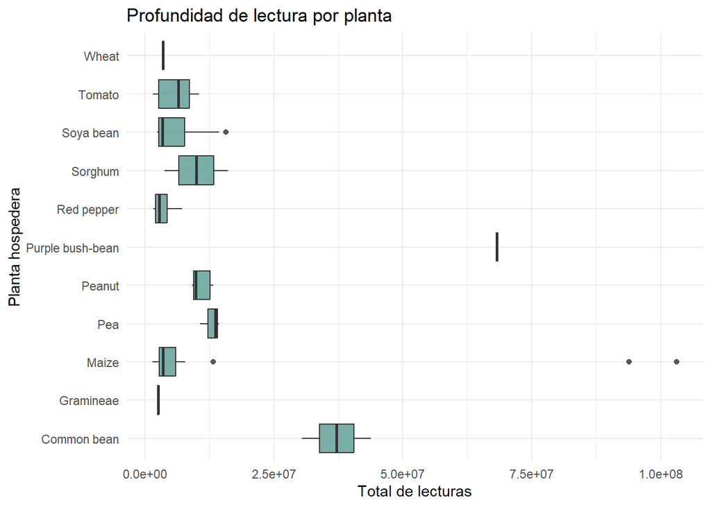

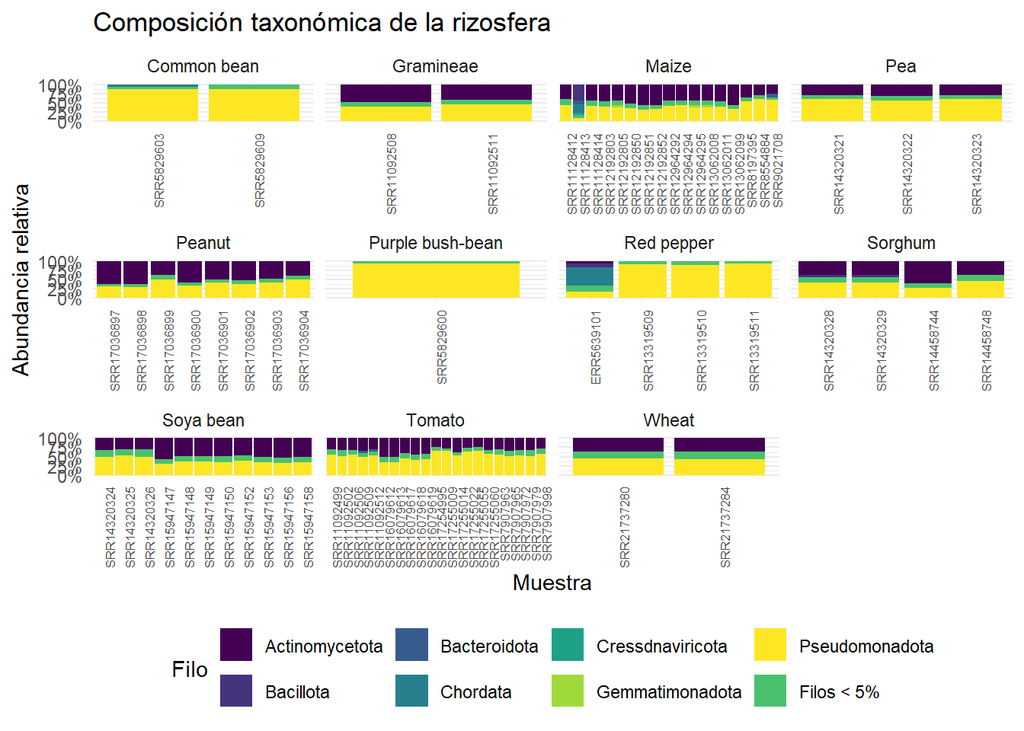

- ¿Qué diferencias o semejanzas se observan entre plantas?

Las plantas pueden compartir varios filos, pero en diferentes proporciones.

- ¿Qué limitaciones tienen las comparaciones?

No todas las plantas tienen la misma cantidad de muestras y estas pueden provenir de diferentes países, estudios y protocolos de secuenciación.

- ¿Qué análisis adicional sería necesario para sustentar una explicación biológica?

Sería necesario realizar pruebas estadísticas para saber si las diferencias observadas son significativas.

- Conclusiones

Se observaron diferencias en la profundidad de lectura y en la composición taxonómica de las muestras. Sin embargo, no podemos asegurar que estas diferencias se deban únicamente a la planta hospedera.